**City College of San Francisco**

MATH 108 - Foundations of Data Science

# Lecture 22: Examples

Associated Textbook Sections: [12.3](https://inferentialthinking.com/chapters/12/3/Deflategate.html)

## Outline

- Benford's Law
- Reaction Time
- Zodiac Signs

## Set Up the Notebook

```python
from datascience import *
import numpy as np
%matplotlib inline
import matplotlib.pyplot as plots
plots.style.use('fivethirtyeight')
```

## Benford's Law

> [Benford's law](https://en.wikipedia.org/wiki/Benford%27s_law), also known as the Newcomb-Benford law, the law of anomalous numbers, or the first-digit law, is an observation that in many real-life sets of numerical data, the leading digit is likely to be small. Benford's law tends to apply most accurately to data that span several orders of magnitude. As a rule of thumb, the more orders of magnitude that the data evenly covers, the more accurately Benford's law applies.

Observe the distribution of the first digits of numbers according to Benford's model.

```python
digits = np.arange(1, 10)
benford_model = np.log10(1 + 1/digits)
benford = Table().with_columns(
    'First digit', digits,
    'Benford model prob', benford_model)
benford
```

| First digit | Benford model prob |
| --- | --- |
| 1 | 0.30103 |
| 2 | 0.176091 |
| 3 | 0.124939 |
| 4 | 0.09691 |
| 5 | 0.0791812 |
| 6 | 0.0669468 |
| 7 | 0.0579919 |
| 8 | 0.0511525 |
| 9 | 0.0457575 |

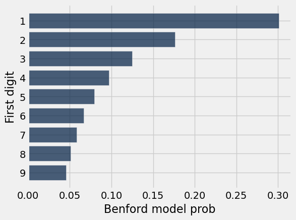

```python
benford.barh('First digit')
```

*The use of bracket notation here is just for an example. Bracket notation is a common way in Python to obtain information within a collection. This is similar to how we use `.item(0)` with arrays.*

```python
a_string = 'data science'
a_string[7]
```

```
'i'
```

Try the same thing with an integer.

```python
# Uncomment this to see a TypeError
an_integer = 1234
# an_integer[0]
```

Explore the `first_digit` function.

```python
def first_digit(num):
    """Returns the first digit of the interger num."""
    return int(str(num)[0])
```

```python
first_digit(6532)
```

```
6
```

Load the `counties.csv` data. This data contains county population sizes from the 2010 Census.

```python
counties = Table.read_table('./data/counties.csv')
counties = counties.where('SUMLEV', 50).select(5,6,9)\
                                       .relabeled(0,'State')\
                                       .relabeled(1,'County')\
                                       .relabeled(2,'Population')

counties
```

| State | County | Population |
| --- | --- | --- |
| Alabama | Autauga County | 54684 |
| Alabama | Baldwin County | 183216 |
| Alabama | Barbour County | 27336 |
| Alabama | Bibb County | 22879 |
| Alabama | Blount County | 57344 |
| Alabama | Bullock County | 10886 |
| Alabama | Butler County | 20945 |
| Alabama | Calhoun County | 118443 |
| Alabama | Chambers County | 34111 |
| Alabama | Cherokee County | 25968 |

... (3132 rows omitted)

```python
counties.where('County', 'San Francisco County')
```

| State | County | Population |
| --- | --- | --- |
| California | San Francisco County | 805825 |

Apply `first_digit` to add a column to the `countries` table that shows the first digit of the population sizes.

```python
first_digits = counties.apply(first_digit, 'Population')
counties = counties.with_column('First digit', first_digits)
counties.show(3)
```

| State | County | Population | First digit |
| --- | --- | --- | --- |
| Alabama | Autauga County | 54684 | 5 |
| Alabama | Baldwin County | 183216 | 1 |
| Alabama | Barbour County | 27336 | 2 |

... (3139 rows omitted)

Visually compare the distribution of first digits from the countries data and Benford's proportions.

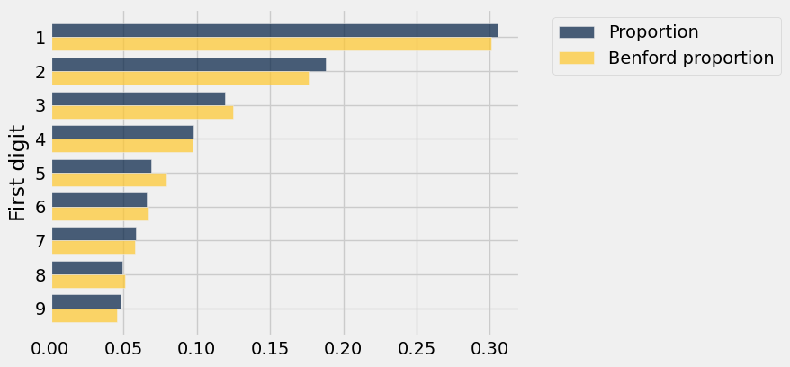

```python
num_counties = counties.num_rows
by_digit = counties.group('First digit')
proportions = by_digit.column('count') / num_counties
by_digit = by_digit.with_columns(
    'Proportion', proportions,
    'Benford proportion', benford_model
)
by_digit.drop('count').barh('First digit')
```

Test whether or not the distribution of proportions in `counties` is consistent with Benford's model.

Null hypothesis: The distribution of the first digits in the counties data set follows Benford's Law.

Alternative hypothesis: The distribution of the first digits in the counties data is different from Benford's Law.

Test statistic: TVD (total variation distance)

Fill in the blank with "Bigger" or "Smaller":

Bigger values of the test statistic favor the alternative

```python
# Calculate the observed statistic
# benford_model from original table creation

observed_tvd = sum(abs(proportions - benford_model))/2
observed_tvd
```

```
0.019227569718005828
```

```python
# Demonstrate how to create simulated random samples
# Use sample_proportions (num_counties is sample size which is number of counties
# defined earlier as num_rows)

sample_proportions(num_counties, benford_model)
```

```
array([ 0.29885423,  0.17695735,  0.12253342,  0.09707193,  0.07511139,
        0.07415659,  0.05283259,  0.05792489,  0.04455761])
```

```python
# Demonstrate how to calculate the test statistic for a simulated random sample

simulated_frequencies = sample_proportions(num_counties, benford_model)
tvd = sum(abs(simulated_frequencies - benford_model))/2
tvd
```

```
0.024714584817947409
```

```python
# Create a function that creats a simulated random sample and calculates the test statistic.

def simulate_county_first_digits():
    simulated_frequencies = sample_proportions(num_counties, benford_model)
    tvd = sum(abs(simulated_frequencies - benford_model))/2
    return tvd
```

```python
# Create an array of 10,000 simulated statistics.

simulated_tvds = make_array()

for _ in np.arange(10000):
    simulated_tvds = np.append(simulated_tvds, simulate_county_first_digits())
```

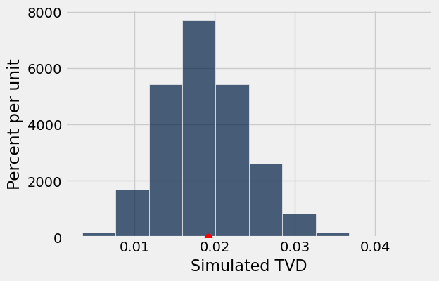

```python
# Visualize the emperical distribution for the simulated statistics
Table().with_column('Simulated TVD', simulated_tvds).hist(0)
plots.scatter(observed_tvd, 0, color='red', s=60, zorder=3)
plots.show()
```

```python
# Calculate the p-value. Find the proportion of simulated test statistic values that
# are larger than the obeserved.

np.count_nonzero(simulated_tvds >= observed_tvd) / 10000
```

```
0.4398
```

Are the data consistent with the null hypothesis?

Yes! With a p-value much larger than I 5% (cutoff), the data are consistent with the null hypothesis.

## Survey Observations

- *The following examples use a real data set (Class Survey) along with the hypothesis testing procedure to come to conclusions.*
- *Keep in mind that data is not form a random sample.*
- *The conclusions we reach should no te taken seriously.*

### Reaction Time

Load our welcome survey data from `welcome_survey_sp23.csv`.

```python
survey = Table.read_table('./data/welcome_survey_sp23.csv')
survey.show(3)
```

| Time | Section | Birthday | Age | DA Cert | DS AS | Born in US | Reaction Time (ms) | Math Experience | Prior Python Experience | Sunrise or Sunset | Weekly Time on Assignments | Career Change | Commute Duration | Required Weekly Work Hours | Zipcode | Programming Language Experience | Number of Countries | Top Movie Genres | Favorite SF Season | Highest Education Level | Veteran | Personality Type | MATH 108 Work Times | Data Science Career Goal | MATH 108 Work Days | Tutoring Format Preference | Sequence Length | Time in San Francisco | Statistics Experience | … |
| --- | --- | --- | --- | --- | --- | --- | --- | --- | --- | --- | --- | --- | --- | --- | --- | --- | --- | --- | --- | --- | --- | --- | --- | --- | --- | --- | --- | --- | --- | --- |
| 2/9/2023 14:23:02 | A | 3/9 | 21 | No | No | Yes | nan | 4 | No | Sunsets | 10 | No | 1:15:00 | 20 | 94703 | nan | 4 | Action & Adventure, Comedies, Sci-fi & Fantasy | Summer | Some college but not a degree | No | Ambivert | 6 am - 10 am, 2 pm - 6 pm | Yes | Thursday, Sunday | In person | nan | 1 | 10 | … |
| 2/9/2023 15:43:41 | A | 4/25 | 35 | Maybe | Maybe | Yes | 283 | 3 | No | Sunrises | 7 | No | 1:30:00 | 28 | 94510 | 2 | 7 | Classic, Comedies, Dramas | Summer | High school graduate | Yes | Introvert | 2 pm - 6 pm, 6 pm - 10 pm | Maybe | Monday, Wednesday | Neither | 11 | 3 | 1 | … |
| 2/9/2023 21:03:44 | A | 7/2 | 21 | No | No | No | 264 | 4 | Yes | Sunsets | 8 | No | 0:30:00 | 18 | 94112 | 3 | 3 | Action & Adventure, Anime, Sci-fi & Fantasy | Spring | Some college but not a degree | No | Introvert | 10 am - 2 pm, 6 pm - 10 pm | Maybe | Friday, Sunday | In person | 10 | 6 | 7 | … |

... (40 rows omitted)

Create a reduced table by selecting the columns:

- `Student Status'`
- `'Reaction Time (ms)'`

```python
status_reaction = (survey.select('Student Status', 'Reaction Time (ms)')
                   .where('Reaction Time (ms)', are.above_or_equal_to(0))
                   .where('Student Status', are.not_equal_to('nan')))
status_reaction
```

| Student Status | Reaction Time (ms) |
| --- | --- |
| Full-time | 283 |
| Full-time | 264 |
| Full-time | 241 |
| Full-time | 359 |
| Full-time | 336 |
| Part-time | 347 |
| Full-time | 319 |
| Full-time | 223 |
| Full-time | 273 |
| Full-time | 208 |

... (23 rows omitted)

```python
status_reaction.group('Student Status')
```

| Student Status | count |
| --- | --- |
| Full-time | 19 |
| Part-time | 14 |

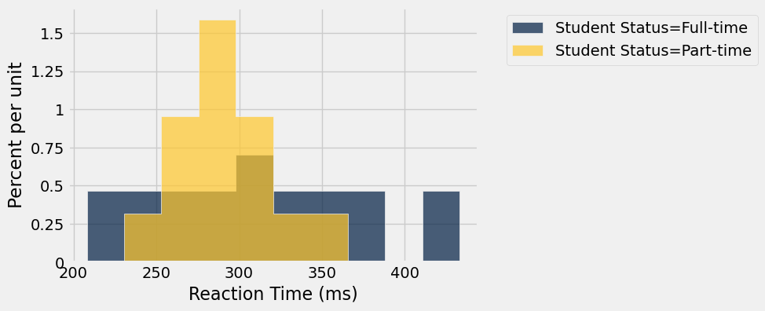

```python
status_reaction.hist('Reaction Time (ms)', group='Student Status')
```

Determine the average reaction time for the two different groups.

```python
status_reaction.group('Student Status', np.average)
```

| Student Status | Reaction Time (ms) average |
| --- | --- |
| Full-time | 312.368 |
| Part-time | 288.5 |

Null hypothesis: **The average reaction time for full-time and part-time students is the same.**

Alternative hypothesis: **The average reaction time for full-time and part-time students is not the same.**

Test statistic: **Absolute difference in the average reaction time for the two groups.**

Fill in the blank with "Bigger" or "Smaller":

**Bigger** values of the test statistic favor the alternative

```python
def compute_test_statistic(tbl):
    grouped = tbl.group('Student Status', np.average)
    avgs = grouped.column('Reaction Time (ms) average')
    return abs(avgs.item(1) - avgs.item(0))
```

```python
obs_test_stat = compute_test_statistic(status_reaction)
obs_test_stat
```

```
23.86842105263156
```

```python
random_labels = status_reaction.sample(with_replacement=False).column('Student Status')
random_labels
```

```
array(['Full-time', 'Full-time', 'Full-time', 'Full-time', 'Part-time',
       'Part-time', 'Full-time', 'Part-time', 'Full-time', 'Part-time',
       'Part-time', 'Part-time', 'Full-time', 'Full-time', 'Part-time',
       'Full-time', 'Full-time', 'Part-time', 'Full-time', 'Full-time',
       'Part-time', 'Part-time', 'Part-time', 'Part-time', 'Full-time',
       'Part-time', 'Full-time', 'Full-time', 'Part-time', 'Full-time',
       'Full-time', 'Full-time', 'Full-time'],
      dtype='<U9')
```

```python
def simulate_under_null():
    random_labels = status_reaction.sample(with_replacement=False).column('Student Status')
    relabeled_tbl = status_reaction.with_column('Student Status', random_labels)
    return compute_test_statistic(relabeled_tbl)
```

```python
simulated_diffs = make_array()

for __ in np.arange(1000):
    null_stat = simulate_under_null()
    simulated_diffs = np.append(simulated_diffs, null_stat)
```

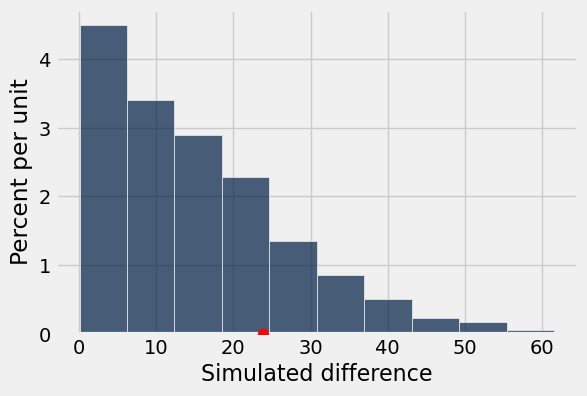

```python
Table().with_column('Simulated difference', simulated_diffs).hist(0)
plots.scatter(obs_test_stat, 0, color='red', s=60, zorder=3)
plots.show()
```

```python
np.mean(simulated_diffs >= obs_test_stat)
```

```
0.20699999999999999
```

Are the results statistically significant?

- **With a p-value larger than 5%, the results are not statistically significant.**
- Notice that the choice of statistic doesn't allow us to see the difference in the shape of the distributions.

## Zodiac Signs

Load the distribution of Zodiac signs in the United States (as found in 2018).

*Source: https://www.statisticbrain.com/zodiac-sign-statistics*

```python
zodiac_distribution = Table.read_table('./data/zodiac_distribution.csv')
zodiac_distribution.show()
```

| Zodiac Sign | Proportion of US Population |
| --- | --- |
| Aquarius | 0.063 |
| Aries | 0.081 |
| Cancer | 0.084 |
| Capricorn | 0.082 |
| Gemini | 0.092 |
| Leo | 0.071 |
| Libra | 0.087 |
| Pisces | 0.09 |
| Sagittarius | 0.073 |
| Scorpio | 0.094 |
| Taurus | 0.083 |
| Virgo | 0.093 |

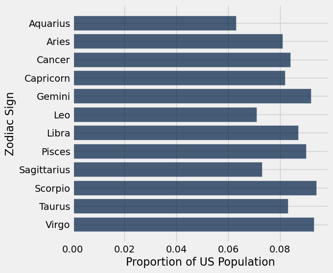

```python
zodiac_distribution.barh('Zodiac Sign')
```

Get the birthdays from the survey data, convert the birthdays to Zodiac signs, and determien the distribution of Zodiac signs in MATH 108.

```python
birthdays = survey.select('Birthday').where('Birthday', are.not_equal_to('nan'))
birthdays
```

| Birthday |
| --- |
| 3/9 |
| 4/25 |
| 7/2 |
| 12/8 |
| 9/29 |
| 2/9 |
| 12/13 |
| 7/28 |
| 1/26 |
| 7/18 |

... (30 rows omitted)

```python
def get_zodiac_sign(birthday):
    """
    Given a birthday in the format "MM/DD",
    returns a string representing the corresponding zodiac sign.
    """
    month, day = map(int, birthday.split("/")) # map is not covered in this class
    if month == 12:
        # a more compact way of writing an if statement
        astro_sign = 'Sagittarius' if (day < 22) else 'Capricorn'
    elif month == 1:
        astro_sign = 'Capricorn' if (day < 20) else 'Aquarius'
    elif month == 2:
        astro_sign = 'Aquarius' if (day < 19) else 'Pisces'
    elif month == 3:
        astro_sign = 'Pisces' if (day < 21) else 'Aries'
    elif month == 4:
        astro_sign = 'Aries' if (day < 20) else 'Taurus'
    elif month == 5:
        astro_sign = 'Taurus' if (day < 21) else 'Gemini'
    elif month == 6:
        astro_sign = 'Gemini' if (day < 21) else 'Cancer'
    elif month == 7:
        astro_sign = 'Cancer' if (day < 23) else 'Leo'
    elif month == 8:
        astro_sign = 'Leo' if (day < 23) else 'Virgo'
    elif month == 9:
        astro_sign = 'Virgo' if (day < 23) else 'Libra'
    elif month == 10:
        astro_sign = 'Libra' if (day < 23) else 'Scorpio'
    elif month == 11:
        astro_sign = 'Scorpio' if (day < 22) else 'Sagittarius'
    else:
        astro_sign = 'Invalid Date'
    return astro_sign
```

```python
def prop_function(count):
    """Return the count provided as a proportion of 40 (# of respondents)."""
    total_number = 40
    return count/40

birthdays = birthdays.with_column(
    'Zodiac Sign',
    birthdays.apply(get_zodiac_sign, 'Birthday')
)

birthdays_by_sign = birthdays.group('Zodiac Sign')
birthdays_by_sign = birthdays_by_sign.with_column(
    'Proportion in MATH 108',
    birthdays_by_sign.apply(prop_function, 'count')
).drop('count').sort('Zodiac Sign')

zodiac = birthdays_by_sign.join('Zodiac Sign', zodiac_distribution)
zodiac.show()
```

| Zodiac Sign | Proportion in MATH 108 | Proportion of US Population |
| --- | --- | --- |
| Aquarius | 0.125 | 0.063 |
| Aries | 0.125 | 0.081 |
| Cancer | 0.15 | 0.084 |
| Capricorn | 0.05 | 0.082 |
| Gemini | 0.05 | 0.092 |
| Leo | 0.025 | 0.071 |
| Libra | 0.075 | 0.087 |
| Pisces | 0.1 | 0.09 |
| Sagittarius | 0.075 | 0.073 |
| Scorpio | 0.1 | 0.094 |
| Taurus | 0.075 | 0.083 |
| Virgo | 0.05 | 0.093 |

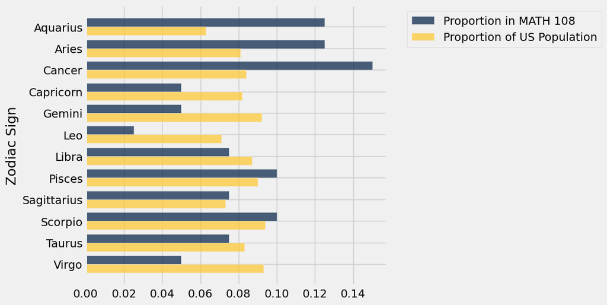

```python
zodiac.barh('Zodiac Sign')
```

Run a test to see if there is a significant difference between the distribution of Zodiac signs in the class and the nation.

```python
observed_tvd_zodiac = np.sum(np.abs(zodiac.column('Proportion in MATH 108')
                              - zodiac.column('Proportion of US Population')))/2
observed_tvd_zodiac
```

```
0.1865
```

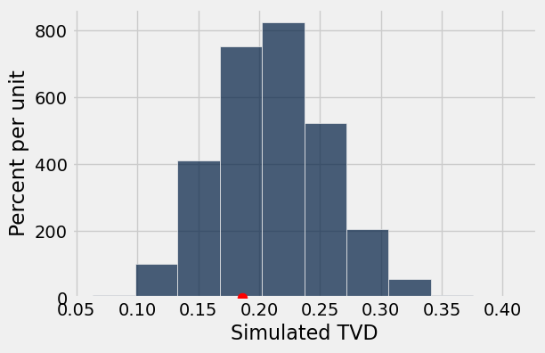

```
0.6913
```

```python
def simulate_zodiac_proportions():
    simulated_proportions = sample_proportions(40, zodiac.column('Proportion of US Population'))
    tvd = np.sum(np.abs(simulated_proportions - zodiac.column('Proportion of US Population'))) / 2
    return tvd

simulated_tvds_zodiac = make_array()

for __ in np.arange(10000):
    simulated_tvds_zodiac = np.append(simulated_tvds_zodiac, simulate_zodiac_proportions())

Table().with_column('Simulated TVD', simulated_tvds_zodiac).hist(0)
plots.scatter(observed_tvd_zodiac, 0, color='red', s=60, zorder=3)
plots.show()

np.count_nonzero(simulated_tvds_zodiac >= observed_tvd_zodiac) / 10000
```

## Test Reflection

- The p-value for the last test wass almost 70%.
- This means that our test results are NOT statistically significant. 🫣
- The course Zodiac distribution looks wildly different form populations distribution.
- How can this be?
  - Sample size has a pretty big impact.
  - Try changing the sample size in `sample_proportions` to 400, instead of 40.

### Hypothesis Test Concerns

The outcome of a hypothesis test can be affected by:

- The hypotheses you investigate:
  - How do you define your null distribution?
- The test statistic you choose:
  - How do you measure a difference between samples?
- The empirical distribution of the statistic under the null:
  - How many times do you simulate under the null distribution?
- The data you collected:
  - Did you happen to collect a sample that is similar to the population?
- The truth:
  - If the alternative hypothesis is true, how extreme is the difference?

### Hypothesis Test Effects

- Number of simulations:
  - large as possible: empirical distribution → true distribution
  - No new data needs to be collected (yay!)
- Number of observations:
  - A larger sample will lead you to reject the null more reliably if the alternative is in fact true.
- Difference from the null:
  - If truth is similar to the null hypothesis, then even a large sample may not provide enough evidence to reject the null.